# Analysis of count/mass systematicity: phonemes

## Individual phonemes, codas only (no open syllables)

Check individual consonants per mass/count distinction:

```r
cons_tab <- with(filter(mono, final_class != 'vowel'),
     table(cnt_mass, final))

# Check:

cons_tab
```

```
##         final
## cnt_mass   B  CH   D   F   G  JH   K   L   M   N  NG   P   R   S  SH   T  TH
##    count  32  36 154  37  37  36 149 245 102 238  16  89  62 105  17 329  14
##    mass    0   1  12   6   1   4  23  16  17  29   2   6   3  39   5  32   3
##         final
## cnt_mass   V   Z  ZH
##    count  22  27   6
##    mass    1   5   2
```

Check standardized residuals:

```r
cons_stdres <- chisq.test(cons_tab)$stdres
round(cons_stdres, 1)
```

```
##         final
## cnt_mass    B   CH    D    F    G   JH    K    L    M    N   NG    P    R    S
##    count  2.0  1.6  1.5 -0.7  1.6  0.1 -1.3  2.5 -1.4 -0.2 -0.1  1.4  1.6 -6.7
##    mass  -2.0 -1.6 -1.5  0.7 -1.6 -0.1  1.3 -2.5  1.4  0.2  0.1 -1.4 -1.6  6.7
##         final
## cnt_mass   SH    T   TH    V    Z   ZH
##    count -1.9  1.2 -1.0  1.0 -0.9 -1.3
##    mass   1.9 -1.2  1.0 -1.0  0.9  1.3
```

Check how many of the continuants are over-represented:

```r
# Extract continuant and occlusive phoneme names:

continuants <- filter(phones,
                      class %in% c('fricative', 'nasal', 'liquid')) %>%
  pull(phoneme)

occlusives <- filter(phones,
                     class %in% c('stop', 'affricate')) %>%
  pull(phoneme)

# Check how many of these continuants are over-represented for

sum(cons_stdres[2, colnames(cons_stdres) %in% continuants] > 0) # positive residual
```

```
## [1] 9
```

```r
sum(cons_stdres[2, colnames(cons_stdres) %in% continuants] < 0) # negative residual
```

```
## [1] 3
```

```r
sum(cons_stdres[2, colnames(cons_stdres) %in% occlusives] > 0) # positive residual
```

```
## [1] 1
```

```r
sum(cons_stdres[2, colnames(cons_stdres) %in% occlusives] < 0) # negative residual
```

```
## [1] 7
```

Calculate the corresponding proportions:

```r
9 / (9 + 3) # 75% of continuant phonemes have positive residuals for mass
```

```
## [1] 0.75
```

```r
7 / (7 + 1) # 87.5% of occlusive phonemes have negative residuals for mass
```

```
## [1] 0.875
```

Create counts of `cnt_mass` versus `continuant`:

```r
continuant_counts <- mono %>%
  count(cnt_mass, continuant) %>%
  group_by(cnt_mass) %>%
  mutate(prop = n/ sum(n))
```

Make a stacked bar plot of occlusive vis-a-vis count/mass:

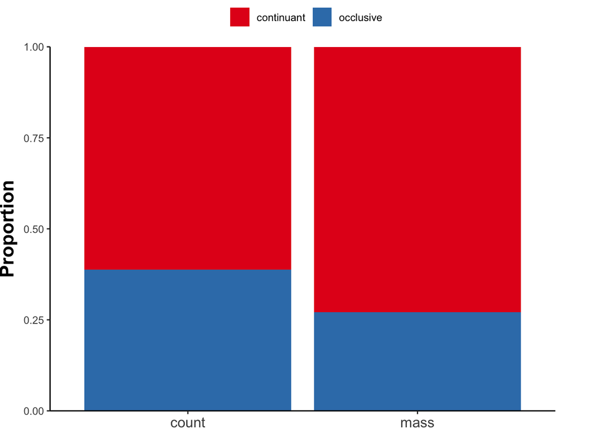

```r
# Plot basics:

cont_p <- continuant_counts %>%
  ggplot(aes(x = factor(cnt_mass),
             y = prop, fill = continuant)) +
  geom_col()

# Axes and labels:

cont_p <- cont_p +
  ylab('Proportion') +
  xlab(NULL) +
  scale_fill_brewer(palette = 'Set1') +
  scale_y_continuous(expand = c(0, 0))

# Cosmetics:

cont_p <- cont_p +
  theme_classic() +
  theme(legend.position = 'top',
        legend.title = element_blank(),
        axis.text.x = element_text(size = 12),
        axis.title.y = element_text(face = 'bold',
                                    size = 16,
                                    margin = margin(r = 5)),
        axis.title.x = element_text(face = 'bold',
                                    size = 16),
        plot.margin = margin(r = 40))

# Show and save:

cont_p
```

```r
ggsave(plot = cont_p,
       filename = '../figures/continuant_stacked_barplot.pdf',
       width = 3, height = 4)
```

## Bayesian models of the consonant patterns

Make the Continuant and FinalClass variable into factors:

```r
mono <- mutate(mono,
               continuant = factor(continuant,
                                   levels = c('occlusive', 'continuant')))
```

Set weakly informative / regularizing priors on beta coefficients. These will be used throughout all models below. This is a bit lazy, but they are all either bernoulli or negative binomial models, and SD = 1 is decently conservative for both types of models.

```r
priors <- c(prior(normal(0, 1), class = b))
```

Logistic regression of occlusive vs. continuant:

```r
occl_mdl <- brm(continuant ~ 1 + cnt_mass + major_etym,
                data = mono,

                # Likelihood function:
                family = bernoulli,

                # Priors:
                prior = priors,

                # MCMC settings:
                init = 0, seed = 666,
                cores = 4, chains = 4,
                warmup = 2000, iter = 4000)
```

```
## Trying to compile a simple C file
```

[output not shown]

```r
# Save:

save(occl_mdl,
     file = '../models/occl_mdl.Rdata')
```

Make the corresponding null model:

```r
occl_null_mdl <- brm(continuant ~ 1 + major_etym,
                     data = mono,

                     # Likelihood function:
                     family = bernoulli,

                     # Priors:
                     prior = priors,

                     # MCMC settings:
                     init = 0, seed = 666,
                     cores = 4, chains = 4,
                     warmup = 2000, iter = 4000)
```

```
## Trying to compile a simple C file
```

[output not shown]

```r
# Save:

save(occl_null_mdl,
     file = '../models/occl_null_mdl.Rdata')
```

Compare R-squared:

```r
# Invidiual Bayes R2 for each model:

bayes_R2(occl_mdl)
```

```
##      Estimate  Est.Error        Q2.5      Q97.5
## R2 0.01069975 0.00360225 0.004339298 0.01848185
```

```r
bayes_R2(occl_null_mdl)
```

```
##       Estimate   Est.Error        Q2.5     Q97.5
## R2 0.005201417 0.002571391 0.001209872 0.0111999
```

```r
# Difference between R2 to get unique contribution of count vs. mass:

bayes_R2(occl_mdl)[, 1] - bayes_R2(occl_null_mdl)[, 1]
```

```
## [1] 0.005498335
```

Check the model:

```r
occl_mdl
```

```
##  Family: bernoulli
##   Links: mu = logit
## Formula: continuant ~ 1 + cnt_mass + major_etym
##    Data: mono (Number of observations: 2516)
##   Draws: 4 chains, each with iter = 4000; warmup = 2000; thin = 1;
##          total post-warmup draws = 8000
##
## Population-Level Effects:
##                    Estimate Est.Error l-95% CI u-95% CI Rhat Bulk_ESS Tail_ESS
## Intercept              0.60      0.10     0.40     0.79 1.00     6483     5674
## cnt_massmass           0.51      0.14     0.23     0.78 1.00     8531     5643
## major_etymgermanic    -0.19      0.11    -0.41     0.02 1.00     6653     6128
## major_etymLatin        0.21      0.18    -0.14     0.56 1.00     7071     6207
## major_etymother       -0.25      0.14    -0.52     0.03 1.00     6666     5989
##
## Draws were sampled using sampling(NUTS). For each parameter, Bulk_ESS
## and Tail_ESS are effective sample size measures, and Rhat is the potential
## scale reduction factor on split chains (at convergence, Rhat = 1).
```

```r
hypothesis(occl_mdl, 'cnt_massmass > 0')
```

```
## Hypothesis Tests for class b:
##           Hypothesis Estimate Est.Error CI.Lower CI.Upper Evid.Ratio Post.Prob
## 1 (cnt_massmass) > 0     0.51      0.14     0.28     0.73        Inf         1
##   Star
## 1    *
## ---
## 'CI': 90%-CI for one-sided and 95%-CI for two-sided hypotheses.
## '*': For one-sided hypotheses, the posterior probability exceeds 95%;
## for two-sided hypotheses, the value tested against lies outside the 95%-CI.
## Posterior probabilities of point hypotheses assume equal prior probabilities.
```

Plot the posterior distribution:

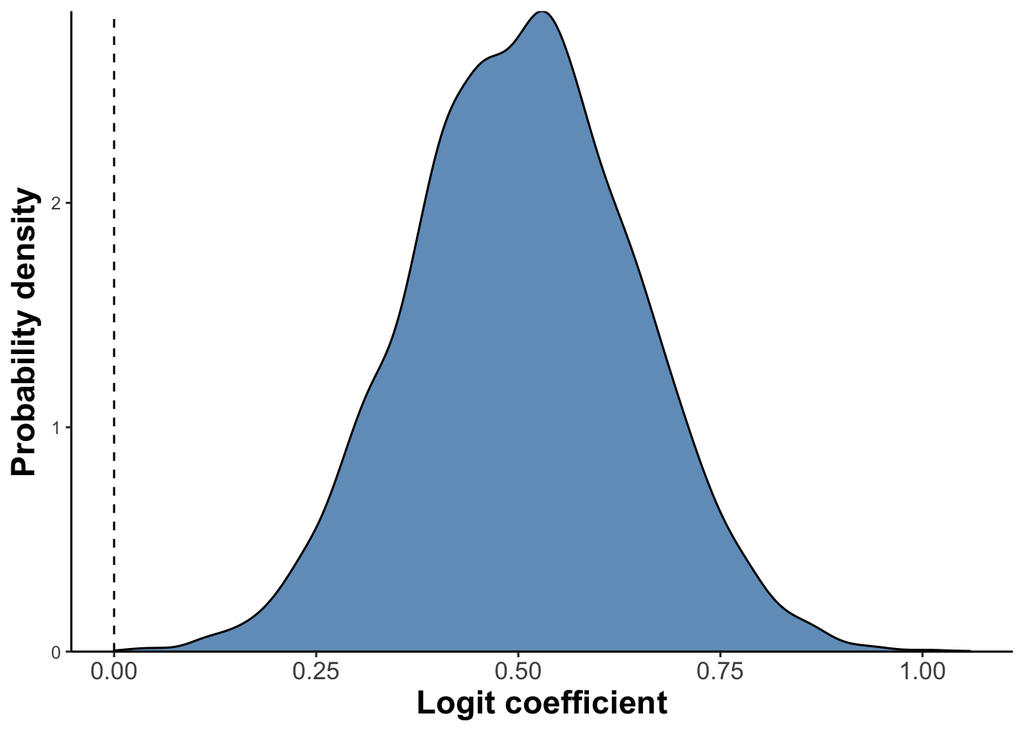

```r
# Plot basics:

occl_post_p <- posterior_samples(occl_mdl) %>%
  ggplot(aes(x = b_cnt_massmass)) +
  geom_vline(xintercept = 0, linetype = 'dashed') +
  geom_density(fill = 'steelblue',
               alpha = 0.8)
# Scales and axes:

occl_post_p <- occl_post_p +
  scale_y_continuous(expand = c(0, 0)) +
  ylab('Probability density') +
  xlab('Logit coefficient')

# Cosmetics:

occl_post_p <- occl_post_p +
  theme_classic() +
  theme(axis.text.x = element_text(size = 12),
        axis.title.y = element_text(face = 'bold',
                                    size = 16,
                                    margin = margin(r = 5)),
        axis.title.x = element_text(face = 'bold',
                                    size = 16))

# Show and save:

occl_post_p
```

```r
ggsave('../figures/occlusives_vs_continuantposterior.pdf', occl_post_p,
       width = 5, height = 3)
```

Extract the conditional effects:

```r
# Extract conditional effects:

occl_cond <- conditional_effects(occl_mdl,
                                 effects = 'cnt_mass')

# Extract data frame with conditional effects and 95% credible intervals:

occl_cond_df <- occl_cond$cnt_mass
```

Make a ggplot out of this:

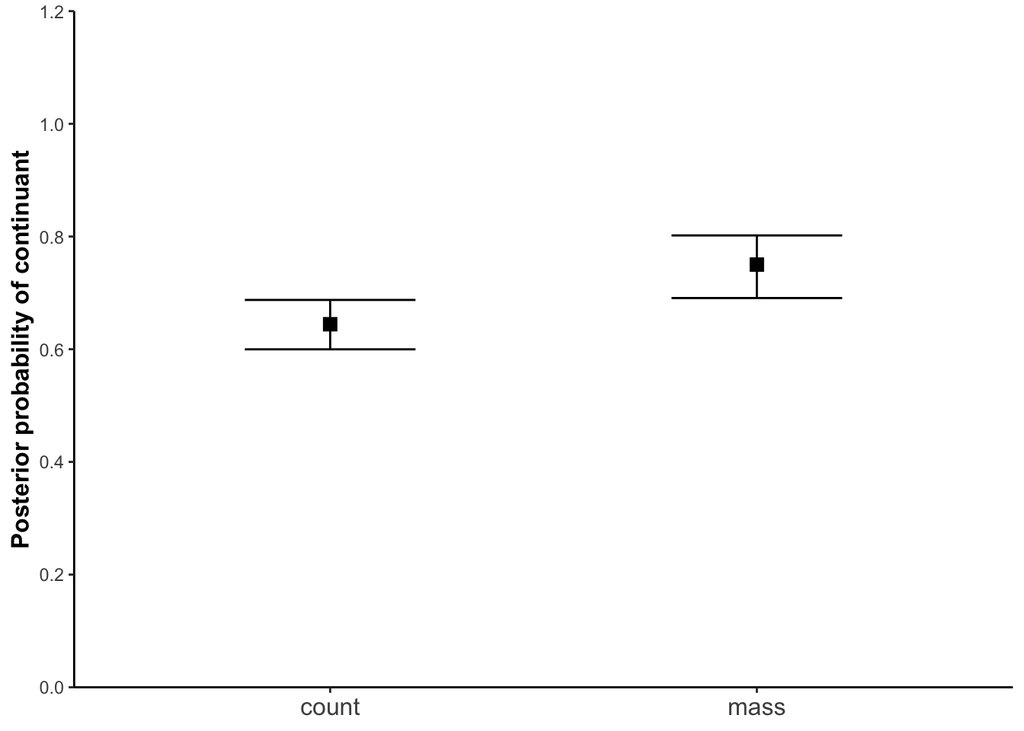

```r
# Plot basics:

occl_cond_p <- occl_cond_df %>%
  ggplot(aes(x = cnt_mass, y = estimate__)) +
  geom_point(size = 3, pch = 15) +
  geom_errorbar(aes(ymin = lower__, ymax = upper__),
                width = 0.4)

# Axes and labels:

occl_cond_p <- occl_cond_p +
  scale_y_continuous(limits = c(0, 1.2), breaks = seq(0, 1.2, 0.2),
                     expand = c(0, 0)) +
  ylab('Posterior probability of continuant') +
  xlab(NULL)

# Cosmetics:

occl_cond_p <- occl_cond_p +
  theme_classic() +
  theme(axis.text.x = element_text(size = 12),
        axis.title.y = element_text(face = 'bold',
                                    size = 12))

# Show and save:

occl_cond_p
```

```r
ggsave(plot = occl_cond_p,
       filename = '../figures/occl_conditional_effects.pdf',
       width = 2, height = 3.5)
```

This completes this analysis.